# Generalized Linear Models

Alexander J Ohrt (Alex-Alex-Helena)

22 september, 2021

[This](https://www.statmethods.net/advstats/glm.html) is the website that we will be reproducing in this task.

Generalized linear models are fit using the **glm()** function. The form of the **glm** function is

**glm(**formula, **family=***familytype*(**link=***linkfunction***)**, **data=)**

| **Family** | **Default Link Function** |
| --- | --- |
| binomial | (link = “logit”) |
| gaussian | (link = “identity”) |
| Gamma | (link = “inverse”) |
| inverse.gaussian | (link = “1/mu^2”) |
| poisson | (link = “log”) |
| quasi | (link = “identity”, variance = “constant”) |
| quasibinomial | (link = “logit”) |
| quasipoisson | (link = “log”) |

See **help(glm)** for other modeling options. See **help(family)** for other allowable link functions for each family. Three subtypes of generalized linear models will be covered here: logistic regression, poisson regression, and survival analysis.

## Logistic Regression

Logistic regression is useful when you are predicting a binary outcome from a set of continuous predictor variables. It is frequently preferred over [discriminant function](https://www.statmethods.net/advstats/discriminant.html) analysis because of its less restrictive assumptions.

```r
# Logistic Regression
# where F is a binary factor and
# x1-x3 are continuous predictors
# Simulate some data (just to get some output)
fit <- glm(z~x+y,data=mydata,family=binomial())
summary(fit) # display results
confint(fit) # 95% CI for the coefficients
exp(coef(fit)) # exponentiated coefficients
exp(confint(fit)) # 95% CI for exponentiated coefficients
predict(fit, type="response") # predicted values
residuals(fit, type="deviance") # residuals
```

You can use **anova**(*fit1*,*fit2*, **test=“Chisq”**) to compare nested models. Additionally, **cdplot**(*F~x*, **data**=mydata) will display the conditional density plot of the binary outcome F on the continuous x variable.

## Poisson Regression

Poisson regression is useful when predicting an outcome variable representing counts from a set of continuous predictor variables.

```r
# Poisson Regression
# where count is a count and
# x1-x3 are continuous predictors
fit <- glm(count ~ x1+x2+x3, data=mydata, family=poisson())
summary(fit) # display results
```

If you have overdispersion (see if residual deviance is much larger than degrees of freedom), you may want to use **quasipoisson()** instead of **poisson()**.

## Survival Analysis

Survival analysis (also called event history analysis or reliability analysis) covers a set of techniques for modeling the time to an event. Data may be **right censored** - the event may not have occured by the end of the study or we may have incomplete information on an observation but know that up to a certain time the event had not occured (e.g. the participant dropped out of study in week 10 but was alive at that time).

While generalized linear models are typically analyzed using the **glm( )** function, survival analysis is typically carried out using functions from the [survival](https://cran.r-project.org/web/packages/survival/index.html) package. The survival package can handle one and two sample problems, parametric accelerated failure models, and the Cox proportional hazards model.

Data are typically entered in the format *start time*, *stop time*, and *status* (1=event occured, 0=event did not occur). Alternatively, the data may be in the format *time to event* and *status* (1=event occured, 0=event did not occur). A status=0 indicates that the observation is right cencored. Data are bundled into a **Surv object** via the **Surv( )** function prior to further analyses.

**survfit( )** is used to estimate a survival distribution for one or more groups.

**survdiff( )** tests for differences in survival distributions between two or more groups.

**coxph( )** models the hazard function on a set of predictor variables.

```r
# Mayo Clinic Lung Cancer Data
library(survival)

# learn about the dataset
help(lung)

# create a Surv object
survobj <- with(lung, Surv(time,status))

# Plot survival distribution of the total sample
# Kaplan-Meier estimator
fit0 <- survfit(survobj~1, data=lung)
summary(fit0)

# Compare the survival distributions of men and women
fit1 <- survfit(survobj~sex,data=lung)

# test for difference between male and female
# survival curves (logrank test)
survdiff(survobj~sex, data=lung)

# predict male survival from age and medical scores
MaleMod <- coxph(survobj~age+ph.ecog+ph.karno+pat.karno,
  data=lung, subset=sex==1)

# display results
MaleMod

# evaluate the proportional hazards assumption
cox.zph(MaleMod)
```

[output not shown]

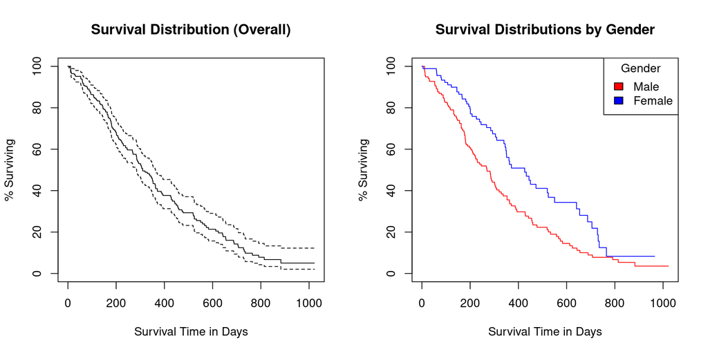

```r
par(mfrow=c(1,2))
plot(fit0, xlab="Survival Time in Days",
   ylab="% Surviving", yscale=100,
   main="Survival Distribution (Overall)")

# plot the survival distributions by sex
plot(fit1, xlab="Survival Time in Days",
  ylab="% Surviving", yscale=100, col=c("red","blue"),
  main="Survival Distributions by Gender")
  legend("topright", title="Gender", c("Male", "Female"),
  fill=c("red", "blue"))
```

See Thomas Lumley’s [R news article](https://cran.r-project.org/doc/Rnews/Rnews_2004-1.pdf) on the survival package for more information. Other good sources include Mai Zhou’s [Use R Software to do Survival Analysis and Simulation](https://www.r-project.org/doc/Rnews/Rnews_2004-1.pdf#page=26) and M. J. Crawley’s chapter on [Survival Analysis](http://www3.imperial.ac.uk/portal/pls/portallive/docs/1/1171928.PDF).

## To Practice

Try this [interactive exercise on basic logistic regression with R](https://campus.datacamp.com/courses/introduction-to-credit-risk-modeling-in-r/chapter-2-logistic-regression?ex=2) using age as a predictor for credit risk.